# Coursework Report

*N* removed NAs: 3

*N* removed typo: 1

*N* removed <18: 19

*N* total clean: 127

| Group | *N* | *M*<sub>age</sub> | *M*<sub>rating</sub> |
| --- | --- | --- | --- |
| Control | 65 | 21.4 | 6.11 |
| Experim | 62 | 21.0 | 7.05 |

**Main analysis results**

*t*(125) = -6.76, *p* < .001

[interactive chart not shown]

[figure not shown]

[interactive chart not shown]

# Coursework Report

Analysing Data, Spring 2020

# Method

## Participants

*Figure 1. Descriptive statistics by Condition*

| Condition | *n* | perc | Mean age | SD age |
| --- | --- | --- | --- | --- |
| White | 65 | 51.2 | 21.4 | 2.39 |
| Red | 62 | 48.8 | 21.0 | 1.97 |

## Design

The aim of this study was to assess whether colour influence attractiveness. To obtain the results shown in this report, participants were shown one of two pictures in a frame that would only change in colour, respectively white or red. Participants had, then, to rate the attractiveness of the person shown in the framed picture on a scale from 1 to 9 after answering three questions: how attractive do you think this person is? How pleasant is this person to look at? If you were to meet the person in this picture face to face would you think he or she is attractive?

Colour, the thing we are manipulating, it’s our independent categorical variable, used to proceed into the study. The second one is attractiveness, a continuous variable, valued as a rating on a scale from 1-9 where the higher score stands for more attractiveness. Attractiveness was the outcome of the study because it is the thing that changes depending on our manipulation.

# Results

*Figure 2. Results*

| Group | Mean Score | Standard Deviation | Minimum Score | Maximum Score | Range |
| --- | --- | --- | --- | --- | --- |
| White | 6.11 | 0.74 | 4.33 | 7.67 | 3.33 |
| Red | 7.05 | 0.83 | 5.00 | 8.67 | 3.67 |

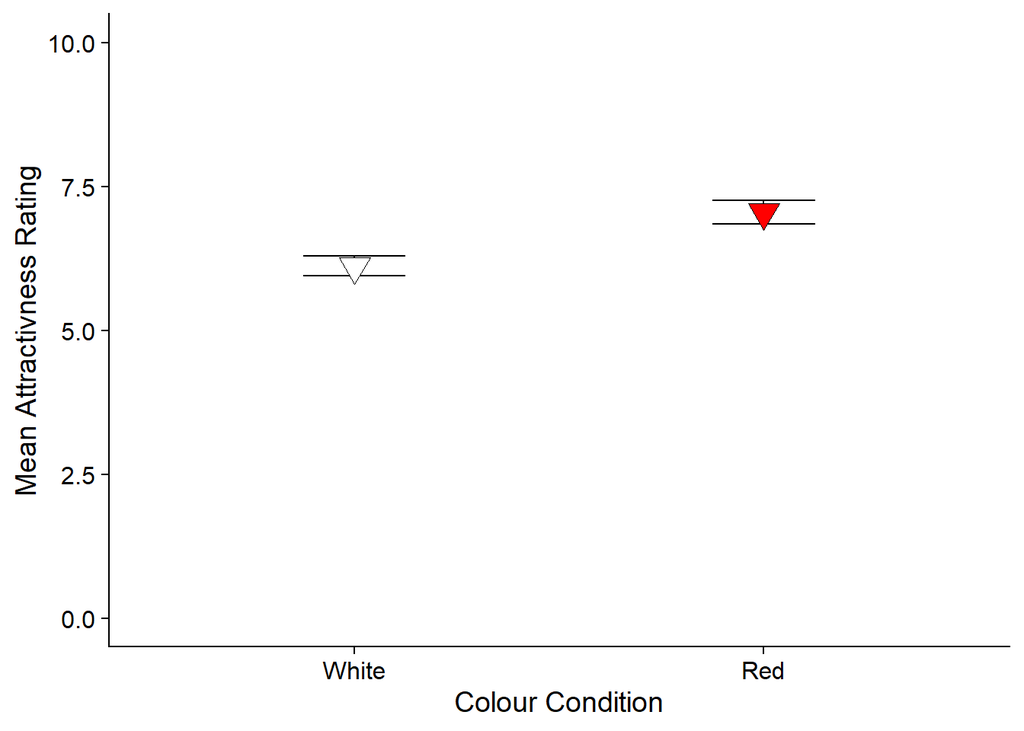

# Discussion

As stated above, this statistical study was effective in assessing that Colour Conditioning plays a significant role in attractiveness. Red, in particular, showed a great response on the attractiveness rating scale, clouding considerably the effects of the colour white. The results of the study offer confirmation of the already substantial findings of Elliot’s study. His study, conducted in four different countries, makes undeniable the fact that colours play a fundamental role in our cognitive responses to stimuli. The results pattern of this study is not far different from the results of the seven experiments conducted in Elliot’s research and this encouraging for the researchers involved in this field.

However, the amount of experiments conducted about this topic is still not enough to make it a universally recognized truth. One of the main reasons is the fact that most of these studies recruit females as participants and focus on heterosexual dynamics. It is undeniable, due to the results of this and other studies, that colour red makes men more attractive to women but there is still a world of possibilities and combination to explore. It would be then very interesting to switch this norm to investigate more about the role of colours on attractiveness also in homosexuals dynamics. And when done so, will we be able to assess If is there any difference between lesbians or gays participants? Being attracted to a woman, as a woman, differ what a person perceives as attractive in a colour palette? Or is it the other way round?

Women have been confirmed to be more sensitive in detecting the colour red (Hurlbert & Ling, 2007) compared to men, so this could mean that women could perceive undertones in people skin easier, especially if we are talking about a red/pink undertone. Could it be possible for women to feel more attracted to a man because of his red undertones or is attractiveness only correlated to objects on (and around) the person observed? And If this were the case, could makeup, as red lipstick, for example, play a role in attractiveness? Nancy Etcoff, American psychologist extensively recognized in the beauty world, explained in her book “Survival of the Prettiest: The Science of Beauty” published in 1999 that red on the lips and the cheeks are seen as sexual signs which ‘mimick youth, nulliparity and vigour of health’.

Moving away for a second from body attractiveness, we should focus also on why people prefer certain colours. When we eat or when we have to choose an object, like a piece of furniture or clothing, colours play a fundamental role in decision-making. Why is that? And which colours are effectively more appealing to our eyes and brains? Biologist Theodosius Dobzhansky, conducted a study in the 70s were participants had to rate colours based on their preferences, finding out that bright colours are generally more prefered than more pastel colours and brown and olive green are the least favourite ones. Interestingly, the researcher found out that colour preferences changed from country to country. Could it be possible for social and cultural contexts to make this big of a difference? If so, does evolution have something to do with it? Do people nowadays prefer different colours from bach then? It would be rather interesting to investigate further. A significant limitation to this study is also the absence of correlation between the colour and an object. Proceeding with further studies, including the comparison of nowadays’ society results and our ancestors’, we could find all the answers to our questions.

All in all, as exposed up above there are other very interesting routes that we could undertake in this field of research, dissipating doubts and deepening a rather neglected sphere of inquiry. But, to this day, we can certainly affirm that red, among all colours, does affect attractiveness.

# References

Elliot, A. J., Niesta Kayser, D., Greitemeyer, T., Lichtenfeld, S., Gramzow, R. H., Maier, M. A., & Liu, H. (2010). Red, rank, and romance in women viewing men. *Journal of Experimental Psychology: General, 139*(3), 399.

(2016)*The Science Behind Classic Red Lipstick.* The Scientific Beauty. http://www.thescientificbeauty.com/science-classic-red-lipstick/.

R. D. Field (2011). *Why We Prefer Certain Colors*. Psychology Today. https://www.psychologytoday.com/us/blog/the-new-brain/201104/why-we-prefer-certain-colors.